# STA302 Group 85 Project Proposal

Now that we have addressed the assumptions of linear regression for the initial model we procede with F test for overall model significance

```r
transformedFitted5 <- lm (cnt ~ temp+ log(windspeed+1)  + log(hum^2) + is_winter + I(workingday == 1), data = hourData)

vif(transformedFitted5)
```

```
              temp log(windspeed + 1)         log(hum^2)
          1.548592           1.096962           1.161382
         is_winter I(workingday == 1)
          1.494664           1.006700
```

```r
summary(transformedFitted5)
```

```
Call:
lm(formula = cnt ~ temp + log(windspeed + 1) + log(hum^2) + is_winter +
    I(workingday == 1), data = hourData)

Residuals:
    Min      1Q  Median      3Q     Max
-533.25  -79.35   10.87   95.54  403.44

Coefficients:
                       Estimate Std. Error t value Pr(>|t|)
(Intercept)              49.351     18.097   2.727  0.00649
temp                    405.181     26.389  15.354  < 2e-16
log(windspeed + 1)       20.698     42.752   0.484  0.62839
log(hum^2)              -52.858      5.893  -8.970  < 2e-16
is_winter              -139.995     11.638 -12.029  < 2e-16
I(workingday == 1)TRUE  322.839      8.875  36.377  < 2e-16

(Intercept)            **
temp                   ***
log(windspeed + 1)
log(hum^2)             ***
is_winter              ***
I(workingday == 1)TRUE ***
---
Signif. codes:
0 ‘***’ 0.001 ‘**’ 0.01 ‘*’ 0.05 ‘.’ 0.1 ‘ ’ 1

Residual standard error: 136.3 on 1088 degrees of freedom
Multiple R-squared:  0.696, Adjusted R-squared:  0.6946
F-statistic: 498.2 on 5 and 1088 DF,  p-value: < 2.2e-16
```

since the p-value for the F test is less than the 0.05 significance threshold we reject the null hypothesis in favor of the alternative. That is to conclude that the model as a whole is significant and at least one of the predictors in the model is significantly related to bike rentals counts.

Now we proceed with variable selection which drops the wind speed as a predictor.

```r
# Perform backward selection based on BIC
backwardBICModel <- step(transformedFitted5, direction = "backward", k = log(nrow(hourData)))
```

```
Start:  AIC=10788.99
cnt ~ temp + log(windspeed + 1) + log(hum^2) + is_winter + I(workingday ==
    1)

                     Df Sum of Sq      RSS   AIC
- log(windspeed + 1)  1      4352 20204207 10782
<none>                            20199855 10789
- log(hum^2)          1   1493754 21693609 10860
- is_winter           1   2686393 22886249 10919
- temp                1   4376907 24576762 10997
- I(workingday == 1)  1  24568127 44767982 11653

Step:  AIC=10782.23
cnt ~ temp + log(hum^2) + is_winter + I(workingday == 1)

                     Df Sum of Sq      RSS   AIC
<none>                            20204207 10782
- log(hum^2)          1   1668606 21872813 10862
- is_winter           1   2682058 22886265 10912
- temp                1   4372573 24576780 10990
- I(workingday == 1)  1  24602134 44806341 11647
```

```r
# Display the summary of the selected model
summary(backwardBICModel)
```

```
Call:
lm(formula = cnt ~ temp + log(hum^2) + is_winter + I(workingday ==
    1), data = hourData)

Residuals:
    Min      1Q  Median      3Q     Max
-529.76  -78.03   10.47   95.86  401.85

Coefficients:
                       Estimate Std. Error t value Pr(>|t|)
(Intercept)              52.488     16.892   3.107  0.00194
temp                    404.753     26.365  15.352  < 2e-16
log(hum^2)              -53.653      5.658  -9.484  < 2e-16
is_winter              -139.754     11.624 -12.023  < 2e-16
I(workingday == 1)TRUE  322.612      8.859  36.415  < 2e-16

(Intercept)            **
temp                   ***
log(hum^2)             ***
is_winter              ***
I(workingday == 1)TRUE ***
---
Signif. codes:
0 ‘***’ 0.001 ‘**’ 0.01 ‘*’ 0.05 ‘.’ 0.1 ‘ ’ 1

Residual standard error: 136.2 on 1089 degrees of freedom
Multiple R-squared:  0.6959,    Adjusted R-squared:  0.6948
F-statistic: 623.1 on 4 and 1089 DF,  p-value: < 2.2e-16
```

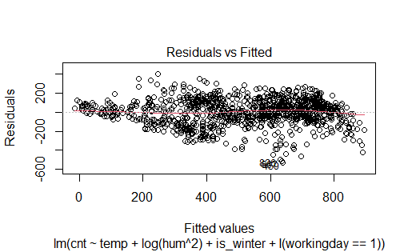

```r
# Plot the residuals vs fitted values for the final model
plot(backwardBICModel, which = 1)  # Residuals vs Fitted
```

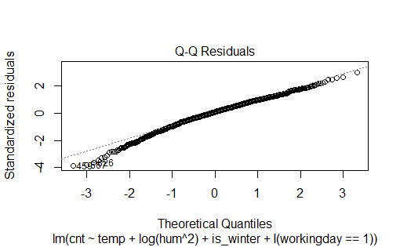

```r
# Plot normal Q-Q plot
plot(backwardBICModel, which = 2)  # Normal Q-Q plot
```

```r
# Set up a 1x2 plot layout
par(mfrow = c(1, 2))

# Plot the residuals vs fitted values for the final model
plot(initialFitted, which = 2)

# Plot the normal Q-Q plot
plot(backwardBICModel, which = 2)  # Normal Q-Q plot
```

```r
# Save the combined plot as an image with specific dimensions and resolution
dev.copy(png, "IMAGES/qq_residuals_compare.png", width = 1200, height = 600, res = 150)  # Save the plot as a PNG file
```

[figure not shown]

```r
dev.off()  # Close the device
```

```r
# Fit the linear model with Winter and Working Day as binary indicators
fitted0 <-lm (sqrt(cnt) ~ temp + windspeed + hum + is_winter + I(workingday == 1), data = hourData)
fitted1 <-lm (cnt ~ temp + log(windspeed + 1) + log(hum^2) + is_winter + I(workingday == 1), data = hourData)

par(mfrow = c(1, 2))

# QQ plot for the initial model
plot(fitted0, which = 2)  # Normal Q-Q plot for initial model

# QQ plot for the final model (transformed response)
plot(fitted1, which = 2)  # Normal Q-Q plot for final model
```

```r
dev.copy(png, "IMAGES/qq_residuals_compare.png", width = 1200, height = 600, res = 150)
```

[figure not shown]

```r
dev.off()
```